# Correlation-Based Meta-Analytic Structural Equation Modeling (MASEM)

UV9216 General Course in Meta-Analysis

Data Example: Technology Acceptance Model (Scherer & Teo, 2019)

# Context

This illustrative example is based on the meta-analytic data set provided by Scherer and Teo (2019), https://doi.org/10.1016/j.edurev.2019.03.001.

The data were extracted from primary studies that (a) contained teacher samples (i.e., either in- or pre-service teachers in primary or secondary education); (b) examined the relations among the four core variables of technology acceptance (ATT = attitudes toward technology, BI = Intentions to use technology, PEU = Perceived ease of use, PU = Perceived usefulness); and (c) reported the correlations between these variables or structural equation model parameters that allowed the meta-analysts to trace back the correlations.

# Preparation and data input

## Install and load relevant `R` packages

```r
# Install R packages (if needed)
# install.packages("OpenMx")
# install.packages("metaSEM")
# install.packages("semPlot")
# install.packages("lavaan")

# Load packages
library(metaSEM)
library(semPlot)
library(lavaan)
library(OpenMx)
```

## Data input and preparation

```r
## Uncorrected correlations
## Constructs: PU, PEU, ATT, and BI

# Read in the correlations
TAMu <- matrix(
    c(1,0.61,1,0.6776,0.5138,1,0.599184,0.449892,0.860328,1,
        1,0.661,1,0.59,0.584,1,0.75,0.746,0.684,1,
        1,0.5,1,0.64,0.55,1,0.55,0.48,0.59,1,
        1,0.512,1,0.461,0.754,1,0.364,0.669,0.595,1,
        1,0.279,1,0.63,0.873,1,0.319,0.441,0.505,1,
        1,0.68,1,0.68,0.73,1,0.34,0.3,0.3,1,
        1,0.4,1,0.56,0.43,1,0.23,0.32,0.36,1,
        1,0.329,1,0.565,0.349,1,0.523,0.327,0.462,1,
        1,0.136,1,0.625,0.1,1,0.436,0.1,0.514,1,
        1,0.467,1,0.634,0.61,1,0.562,0.494,0.681,1,
        1,0.62,1,0.72,0.73,1,0.76,0.6,0.71,1,
        1,0.69,1,0.76,0.71,1,0.03,0.18,0.27,1,
        1,0.067,1,0.207,0.426,1,0.199,0.076,0.006,1,
        1,0.649,1,0.525,0.408,1,0.521,0.406,0.418,1,
        1,0.3,1,0.66,0.52,1,0.57,0.26,0.5,1,
        1,0.44,1,0.62,0.51,1,0.43,0.29,0.36,1,
        1,0.449,1,0.791,0.509,1,0.362,0.217,0.412,1,
        1,0.392,1,0.682,0.446,1,0.327,0.188,0.442,1,
        1,0.11,1,0.75,0.11,1,0.62,0.2,0.67,1,
        1,0.41,1,0.54,0.51,1,0.4,0.43,0.54,1,
        1,0.656,1,0.8358,0.564,1,0.643,0.5431,0.5299,1,
        1,0.33,1,0.63,0.5,1,0.738,0.311,0.527,1,
        1,0.23,1,0.46,0.35,1,0.43,0.19,0.44,1,
        1,0.44,1,0.61,0.48,1,0.68,0.33,0.55,1,
        1,0.72,1,0.71,0.7,1,0.73,0.65,0.68,1,
        1,0.52,1,0.535,0.51,1,0.707,0.553,0.437,1,
        1,0.54,1,0.64,0.56,1,0.54,0.38,0.61,1,
        1,0.53,1,0.63,0.65,1,0.57,0.51,0.69,1,
        1,0.54,1,0.46,0.44,1,0.35,0.22,0.21,1,
        1,0.36,1,0.57,0.48,1,0.16,0.17,0.13,1,
        1,0.44,1,0.63,0.47,1,0.63,0.41,0.62,1,
        1,0.44,1,0.61,0.49,1,0.41,0.3,0.4,1,
        1,0.66,1,0.28,0.2,1,0.58,0.5,0.07,1,
        1,0.53,1,0.81,0.67,1,0.7,0.63,0.69,1,
        1,0.61,1,0.6,0.64,1,0.62,0.59,0.71,1,
        1,0.62,1,0.71,0.55,1,0.66,0.56,0.84,1,
        1,0.575,1,0.486,0.453,1,0.351,0.297,0.447,1,
        1,0.749,1,0.508,0.258,1,0.872,0.743,0.461,1,
        1,0.61,1,0.63,0.67,1,0.64,0.59,0.75,1,
        1,0.31,1,0.23,0.61,1,0.28,0.53,0.53,1,
        1,0.65,1,0.51,0.35,1,0.5,0.41,0.42,1,
        1,0.526,1,0.681,0.585,1,0.654,0.445,0.684,1,
        1,0.307,1,0.632,0.462,1,0.586,0.283,0.446,1,
        1,0.517,1,0.6,0.527,1,0.548,0.405,0.687,1,
        1,0.64,1,0.65,0.65,1,0.61,0.65,0.75,1,
        1,0.26,1,0.549,0.497,1,0.192,0.265,0.249,1,
        1,0.26,1,0.551,0.507,1,0.176,0.101,0.257,1,
        1,0.5376,1,0.6336,0.8396,1,0.8905,0.6887,0.8154,1,
        1,0.709,1,0.885,0.768,1,0.758,0.589,0.783,1,
        1,0.49,1,0.63,0.53,1,0.63,0.46,0.62,1),
    ncol=10, byrow=TRUE)    # fill in correlations row by row with the variances

# Split the above-created matrix into matrices for single studies
# 50 studies in total
# 4x4 correlation matrices
TAMu <- lapply(split(TAMu, 1:50), # split rows into separate studies
                   function(x) {mat <- matrix(1, ncol=4, nrow=4);   # create matrix with 1's
                   mat[upper.tri(mat, diag=TRUE)] <- x;     # fill upper matrix and diagonals
                   mat[lower.tri(mat)] <- t(mat)[lower.tri(mat)];   # fill lower matrix
                   mat})

# Name variables
TAMu <- lapply(TAMu, function(x, var.names) {dimnames(x) <- list(var.names, var.names); x},
                   var.names=c("PU", "PEU", "ATT", "BI"))   # create variable names

# Study names
names(TAMu) <- c("Okazaki & Renda dos Santos (2012)",
                    "Parkman (2015)",
                    "Wong (2015)",
                    "Cote & Miliner (2015)",
                    "Teo & Milutinovic (2015)",
                    "Teo & Fan et al. (2015)-1",
                    "Teo & Fan et al. (2015)-2",
                    "Koutromanos et al. (2015)-1",
                    "Koutromanos et al. (2015)-2",
                    "Wu et al. (2015)",
                    "Kabakci-Yurdakul et al. (2014)",
                    "Kirmizi (2014)",
                    "Mac Callum et al. (2014)",
                    "Wong et al. (2013)",
                    "Teo & Ursavas et al. (2011a)",
                    "Teo & Luan et al. (2008)",
                    "Sumak & Sorgo (2016)-1",
                    "Sumak & Sorgo (2016)-2",
                    "Wu et al. (2016)",
                    "Wong et al. (2016)",
                    "Atif et al. (2015)",
                    "Tokel & Isler (2015)",
                    "Sadeghi et al. (2014)",
                    "Pynoo et al. (2012)",
                    "Aypay et al. (2012)",
                    "Chen & Tseng (2012)",
                    "Teo (2012a)",
                    "Teo & van Schaik (2012)",
                    "Teo & Noyes (2011)",
                    "Teo & Lee et al. (2009a)-1",
                    "Teo & Lee et al. (2009a)-2",
                    "Teo (2009a)",
                    "Park et al. (2007)",
                    "Cheung & Sachs (2006)",
                    "Teo (2011)",
                    "Shiue (2007)",
                    "Chiu (2017)",
                    "Lai et al. (2013)",
                    "Teo & Zhou et al. (2016)",
                    "Teo (2008)",
                    "Wong & Teo et al. (2012)",
                    "Luan & Teo (2009)",
                    "Teo & Ursavas et al. (2012)",
                    "Teo & Zhou (2014)",
                    "Teo (2013)",
                    "Teo & Milutinovic et al. (2016a)-1",
                    "Teo & Milutinovic et al. (2016a)-2",
                    "Pittalis & Christou (2010)",
                    "Fathema et al. (2015)",
                    "Luan & Teo (2011)")

# Sample sizes
TAM.n <- c(446,88,234,29,313,169,170,151,106,340,579,
            213,196,302,197,495,438,460,144,185,184,46,275,
            919,754,402,157,429,153,250,245,475,191,57,592,
            242,306,160,592,139,302,245,487,314,385,226,
            226,105,560,245)

#################
# Combine everything in an object
TAMu <- list(data=TAMu, n=TAM.n)
head(TAMu$data)
```

```
## $`Okazaki & Renda dos Santos (2012)`
##           PU      PEU      ATT       BI
## PU  1.000000 0.610000 0.677600 0.599184
## PEU 0.610000 1.000000 0.513800 0.449892
## ATT 0.677600 0.513800 1.000000 0.860328
## BI  0.599184 0.449892 0.860328 1.000000
##
## $`Parkman (2015)`
##        PU   PEU   ATT    BI
## PU  1.000 0.661 0.590 0.750
## PEU 0.661 1.000 0.584 0.746
## ATT 0.590 0.584 1.000 0.684
## BI  0.750 0.746 0.684 1.000
##
## $`Wong (2015)`
##       PU  PEU  ATT   BI
## PU  1.00 0.50 0.64 0.55
## PEU 0.50 1.00 0.55 0.48
## ATT 0.64 0.55 1.00 0.59
## BI  0.55 0.48 0.59 1.00
##
## $`Cote & Miliner (2015)`
##        PU   PEU   ATT    BI
## PU  1.000 0.512 0.461 0.364
## PEU 0.512 1.000 0.754 0.669
## ATT 0.461 0.754 1.000 0.595
## BI  0.364 0.669 0.595 1.000
##
## $`Teo & Milutinovic (2015)`
##        PU   PEU   ATT    BI
## PU  1.000 0.279 0.630 0.319
## PEU 0.279 1.000 0.873 0.441
## ATT 0.630 0.873 1.000 0.505
## BI  0.319 0.441 0.505 1.000
##
## $`Teo & Fan et al. (2015)-1`
##       PU  PEU  ATT   BI
## PU  1.00 0.68 0.68 0.34
## PEU 0.68 1.00 0.73 0.30
## ATT 0.68 0.73 1.00 0.30
## BI  0.34 0.30 0.30 1.00
```

```r
head(TAMu$n)
```

```
## [1] 446  88 234  29 313 169
```

```r
######################
# Moderator variables
######################

# Type of teacher sample
# Codes: 0=Pre-service teachers, 1=In-service teachers
TS <- c(1,0,0,1,0,0,0,0,1,1,0,0,1,0,0,0,1,1,1,1,1,0,1,1,0,1,
        0,0,0,0,0,0,1,0,1,1,1,1,1,0,0,0,0,0,1,0,0,0,1,0)

# Age in years
Age <- c(NA,NA,25.6,NA,22.44,28.5,28.5,25.8,25.8,NA,NA,NA,
            43.8,23.4,19.4,23.7,44.7,44.5,NA,42.1,NA,22,34.74,
            39.73,21,35.3,22.4,23.69,26.2,24,23.4,23.22,NA,27.8,
            35.3,32.2,NA,NA,35.03,24.2,22.9,23.4,19.41,24.8,
            34.96,22.47,22.47,NA,45.7,23.4)

# Center this variable
Agec <- Age - mean(Age, na.rm = TRUE)

# Continent
# Codes: 1=Asia, 0=Non-Asia
Asia <- c(0,1,1,1,0,1,1,0,0,1,1,1,0,1,1,1,0,0,1,1,0,1,1,
            0,1,1,1,1,1,1,1,1,0,1,1,1,1,1,1,1,1,1,1,1,1,1,0,
            0,0,1)

# Smart-coded technology type
# Codes: 1=Technology in general, 0=Specific technology
Technology <- c(1,0,0,1,1,0,0,1,1,1,0,0,1,0,0,0,1,1,0,0,
                    1,1,0,1,0,1,0,0,0,0,0,0,1,1,0,0,1,1,0,0,
                    0,0,0,0,0,0,0,1,1,0)

# Publication status
# Codes: 1=published, 0=unpublished
Publication <- c(1,0,1,0,1,1,1,1,1,1,1,1,1,1,1,1,1,1,1,
                 1,1,1,1,1,1,1,1,1,1,1,1,1,1,1,1,1,1,1,1,
                 1,1,1,1,1,1,1,1,0,1,1)
```

# Correlation-Based MASEM

## Check the correlation matrices for positive definiteness

```r
# PD check
pd_check <- is.pd(TAMu$data)
sum(!is.na(pd_check))
```

```
## [1] 50
```

```r
pd_check
```

```
##  Okazaki & Renda dos Santos (2012)                     Parkman (2015)
##                               TRUE                               TRUE
##                        Wong (2015)              Cote & Miliner (2015)
##                               TRUE                               TRUE
##           Teo & Milutinovic (2015)          Teo & Fan et al. (2015)-1
##                               TRUE                               TRUE
##          Teo & Fan et al. (2015)-2        Koutromanos et al. (2015)-1
##                               TRUE                               TRUE
##        Koutromanos et al. (2015)-2                   Wu et al. (2015)
##                               TRUE                               TRUE
##     Kabakci-Yurdakul et al. (2014)                     Kirmizi (2014)
##                               TRUE                               TRUE
##           Mac Callum et al. (2014)                 Wong et al. (2013)
##                               TRUE                               TRUE
##       Teo & Ursavas et al. (2011a)           Teo & Luan et al. (2008)
##                               TRUE                               TRUE
##             Sumak & Sorgo (2016)-1             Sumak & Sorgo (2016)-2
##                               TRUE                               TRUE
##                   Wu et al. (2016)                 Wong et al. (2016)
##                               TRUE                               TRUE
##                 Atif et al. (2015)               Tokel & Isler (2015)
##                               TRUE                               TRUE
##              Sadeghi et al. (2014)                Pynoo et al. (2012)
##                               TRUE                               TRUE
##                Aypay et al. (2012)                Chen & Tseng (2012)
##                               TRUE                               TRUE
##                        Teo (2012a)            Teo & van Schaik (2012)
##                               TRUE                               TRUE
##                 Teo & Noyes (2011)         Teo & Lee et al. (2009a)-1
##                               TRUE                               TRUE
##         Teo & Lee et al. (2009a)-2                        Teo (2009a)
##                               TRUE                               TRUE
##                 Park et al. (2007)              Cheung & Sachs (2006)
##                               TRUE                               TRUE
##                         Teo (2011)                       Shiue (2007)
##                               TRUE                               TRUE
##                        Chiu (2017)                  Lai et al. (2013)
##                               TRUE                               TRUE
##           Teo & Zhou et al. (2016)                         Teo (2008)
##                               TRUE                               TRUE
##           Wong & Teo et al. (2012)                  Luan & Teo (2009)
##                               TRUE                               TRUE
##        Teo & Ursavas et al. (2012)                  Teo & Zhou (2014)
##                               TRUE                               TRUE
##                         Teo (2013) Teo & Milutinovic et al. (2016a)-1
##                               TRUE                               TRUE
## Teo & Milutinovic et al. (2016a)-2         Pittalis & Christou (2010)
##                               TRUE                               TRUE
##              Fathema et al. (2015)                  Luan & Teo (2011)
##                               TRUE                               TRUE
```

```r
# Some description of the studies
# Available studies per correlation
pattern.na(TAMu$data, show.na=FALSE)
```

```
##     PU PEU ATT BI
## PU  50  50  50 50
## PEU 50  50  50 50
## ATT 50  50  50 50
## BI  50  50  50 50
```

```r
# Available sample sizes per correlation
pattern.n(TAMu$data, TAMu$n)
```

```
##        PU   PEU   ATT    BI
## PU  14918 14918 14918 14918
## PEU 14918 14918 14918 14918
## ATT 14918 14918 14918 14918
## BI  14918 14918 14918 14918
```

All 50 correlation matrices are positive definite and can be submitted to stage 1 of the correlation-based MASEM approach (i.e., two-stage SEM). If some correlation matrices were not positive definite, we would either have to exclude them or find the nearest positive definite matrix (using the `nearPD()` function in the `Matrix` package).

Notice that none of the correlations were missing.

## Two-Stage MASEM

### Stage 1: Pooling of correlation matrices

#### Pooling under a random-effects model

```r
# Combine correlation matrices using a REM
#
rem <- tssem1(TAMu$data, TAMu$n,
                method = "REM",
                RE.type = "Diag")

# Summarize the results
summary(rem)
```

```
##
## Call:
## meta(y = ES, v = acovR, RE.constraints = Diag(paste0(RE.startvalues,
##     "*Tau2_", 1:no.es, "_", 1:no.es)), RE.lbound = RE.lbound,
##     I2 = I2, model.name = model.name, suppressWarnings = TRUE,
##     silent = silent, run = run)
##
## 95% confidence intervals: z statistic approximation (robust=FALSE)
## Coefficients:
##             Estimate Std.Error    lbound    ubound z value  Pr(>|z|)
## Intercept1 0.4828802 0.0217706 0.4402105 0.5255499 22.1803 < 2.2e-16 ***
## Intercept2 0.6068160 0.0174683 0.5725787 0.6410533 34.7381 < 2.2e-16 ***
## Intercept3 0.5153033 0.0254332 0.4654551 0.5651514 20.2611 < 2.2e-16 ***
## Intercept4 0.5276429 0.0209277 0.4866253 0.5686604 25.2127 < 2.2e-16 ***
## Intercept5 0.4089908 0.0220210 0.3658304 0.4521512 18.5727 < 2.2e-16 ***
## Intercept6 0.5187087 0.0259696 0.4678093 0.5696081 19.9737 < 2.2e-16 ***
## Tau2_1_1   0.0210148 0.0047131 0.0117772 0.0302524  4.4588 8.243e-06 ***
## Tau2_2_2   0.0134545 0.0030663 0.0074446 0.0194643  4.3878 1.145e-05 ***
## Tau2_3_3   0.0298527 0.0064754 0.0171612 0.0425443  4.6102 4.023e-06 ***
## Tau2_4_4   0.0195271 0.0044114 0.0108809 0.0281733  4.4265 9.578e-06 ***
## Tau2_5_5   0.0210140 0.0048452 0.0115176 0.0305103  4.3371 1.444e-05 ***
## Tau2_6_6   0.0312785 0.0066695 0.0182064 0.0443505  4.6897 2.735e-06 ***
## ---
## Signif. codes:  0 '***' 0.001 '**' 0.01 '*' 0.05 '.' 0.1 ' ' 1
##
## Q statistic on the homogeneity of effect sizes: 3622.949
## Degrees of freedom of the Q statistic: 294
## P value of the Q statistic: 0
##
## Heterogeneity indices (based on the estimated Tau2):
##                              Estimate
## Intercept1: I2 (Q statistic)   0.9178
## Intercept2: I2 (Q statistic)   0.9146
## Intercept3: I2 (Q statistic)   0.9460
## Intercept4: I2 (Q statistic)   0.9217
## Intercept5: I2 (Q statistic)   0.9015
## Intercept6: I2 (Q statistic)   0.9493
##
## Number of studies (or clusters): 50
## Number of observed statistics: 27
## Number of estimated parameters: 12
## Degrees of freedom: 15
## -2 log likelihood: -241.0067
## OpenMx status1: 0 ("0" or "1": The optimization is considered fine.
## Other values may indicate problems.)
```

```r
# Extract the pooled correlation matrix
corr.rem <- vec2symMat(coef(rem, select="fixed"), diag=FALSE)
colnames(corr.rem) <- c("PU", "PEU", "ATT", "BI")
rownames(corr.rem) <- c("PU", "PEU", "ATT", "BI")
corr.rem
```

```
##            PU       PEU       ATT        BI
## PU  1.0000000 0.4828802 0.6068160 0.5153033
## PEU 0.4828802 1.0000000 0.5276429 0.4089908
## ATT 0.6068160 0.5276429 1.0000000 0.5187087
## BI  0.5153033 0.4089908 0.5187087 1.0000000
```

#### Pooling under a fixed-effects model

```r
# Combine correlation matrices using a FEM
fem <- tssem1(TAMu$data, TAMu$n,
                method = "FEM")

# Summarize the results
summary(fem)
```

```
##
## Call:
## tssem1FEM(Cov = Cov, n = n, cor.analysis = cor.analysis, model.name = model.name,
##     cluster = cluster, suppressWarnings = suppressWarnings, silent = silent,
##     run = run)
##
## Coefficients:
##         Estimate Std.Error z value  Pr(>|z|)
## S[1,2] 0.5212537 0.0060657  85.934 < 2.2e-16 ***
## S[1,3] 0.6402167 0.0049079 130.446 < 2.2e-16 ***
## S[1,4] 0.5639943 0.0057288  98.448 < 2.2e-16 ***
## S[2,3] 0.5652784 0.0056750  99.608 < 2.2e-16 ***
## S[2,4] 0.4406021 0.0067116  65.648 < 2.2e-16 ***
## S[3,4] 0.5744811 0.0056529 101.626 < 2.2e-16 ***
## ---
## Signif. codes:  0 '***' 0.001 '**' 0.01 '*' 0.05 '.' 0.1 ' ' 1
##
## Goodness-of-fit indices:
##                                       Value
## Sample size                      14918.0000
## Chi-square of target model        3908.0585
## DF of target model                 294.0000
## p value of target model              0.0000
## Chi-square of independence model 25262.4835
## DF of independence model           300.0000
## RMSEA                                0.2030
## RMSEA lower 95% CI                   0.1977
## RMSEA upper 95% CI                   0.2090
## SRMR                                 0.1432
## TLI                                  0.8523
## CFI                                  0.8552
## AIC                               3320.0585
## BIC                               1082.6233
## OpenMx status1: 0 ("0" or "1": The optimization is considered fine.
## Other values may indicate problems.)
```

```r
# Extract the pooled correlation matrix
coef(fem)
```

```
##            PU       PEU       ATT        BI
## PU  1.0000000 0.5212537 0.6402167 0.5639943
## PEU 0.5212537 1.0000000 0.5652784 0.4406021
## ATT 0.6402167 0.5652784 1.0000000 0.5744811
## BI  0.5639943 0.4406021 0.5744811 1.0000000
```

The fit of the fixed-effects model is marginal and suggests that the data are not represented well. Moreover, the REM indicates some significant heterogeneity of the correlations across studies. This gives reason to prefer the REM over the FEM.

### Stage 2: Structural equation modeling

The pooled correlation matrix is now submitted to SEM.

#### Model 1: Path model with the direct effect

In the first step, we specify the model using the `lavaan` language.

```r
# Model specification
Model1 <- " # Structural parameters
            BI ~ ATT + PU
            ATT ~ PEU + PU
            PU ~ PEU

            # Variance of independent variables
            PEU ~~ 1*PEU
"

# Convert the model into the RAM language
RAM <- lavaan2RAM(Model1,
                  obs.variables = c("PU", "PEU", "ATT", "BI"))

# Declare the matrices in the RAM framework
# A: Matrix of factor loadings and regression coefficients
A <- RAM$A
# S: Matrix of variances and covariances
S <- RAM$S
# F: Matrix indicating manifest or latent variables (0=latent, 1=manifest)
F <- RAM$F

# Check the RAM specification
# Note: The function remains silent if the specification is correct.
checkRAM(A, S, cor.analysis = TRUE)
```

This model is now estimated using the pooled correlation matrix obtained from the stage-1 REM.

```r
# Model estimation
# Confidence intervals are likelihood-ratio based (LBCIs)
TS.Model1 <- tssem2(rem, Amatrix=A, Smatrix=S, Fmatrix=F,
                  intervals.type="LB",
                  diag.constraints = TRUE,
                  model.name = "Model 1 with the direct effect")

# Rerun the model to circumvent convergence issues and get all parameters
TS.Model1 <- rerun(TS.Model1)
```

```
## Polite note from mxTryHard: Hessian not checked as model contains mxConstraints
```

```
## Running Model 1 with the direct effect with 8 parameters
```

```
##
## Beginning initial fit attempt
```

```
## Running Model 1 with the direct effect with 8 parameters
```

```
##
##  Lowest minimum so far:  300.642998541006
```

```
##  OpenMx status code 3 not in list of acceptable status codes, (0,1)
```

```
##
## Beginning fit attempt 1 of at maximum 10 extra tries
```

```
## Running Model 1 with the direct effect with 8 parameters
```

```
##
##  Lowest minimum so far:  269.633614885381
```

```
##  OpenMx status code 3 not in list of acceptable status codes, (0,1)
```

```
##
## Beginning fit attempt 2 of at maximum 10 extra tries
```

```
## Running Model 1 with the direct effect with 8 parameters
```

```
##
##  Fit attempt worse than current best:  1294.51322997265 vs 269.633614885381
```

```
##
## Beginning fit attempt 3 of at maximum 10 extra tries
```

```
## Running Model 1 with the direct effect with 8 parameters
```

```
##
##  Lowest minimum so far:  10.0900021787836
```

```
##  OpenMx status code 6 not in list of acceptable status codes, (0,1)
```

```
##
## Beginning fit attempt 4 of at maximum 10 extra tries
```

```
## Running Model 1 with the direct effect with 8 parameters
```

```
##
##  Lowest minimum so far:  10.0900021787836
```

```
##  OpenMx status code 6 not in list of acceptable status codes, (0,1)
```

```
##
## Beginning fit attempt 5 of at maximum 10 extra tries
```

```
## Running Model 1 with the direct effect with 8 parameters
```

```
##  OpenMx status code 6 not in list of acceptable status codes, (0,1)
```

```
##
## Beginning fit attempt 6 of at maximum 10 extra tries
```

```
## Running Model 1 with the direct effect with 8 parameters
```

```
##
## Solution found
```

```
## Final run, for Hessian and/or standard errors and/or confidence intervals
```

```
## Running Model 1 with the direct effect with 8 parameters
```

```
##
##  Solution found!  Final fit=10.090002 (started at 1564.2536)  (7 attempt(s): 7 valid, 0 errors)
```

```r
# Summarize the model parameters
summary(TS.Model1)
```

```
##
## Call:
## wls(Cov = pooledS, aCov = aCov, n = tssem1.obj$total.n, RAM = RAM,
##     Amatrix = Amatrix, Smatrix = Smatrix, Fmatrix = Fmatrix,
##     diag.constraints = diag.constraints, cor.analysis = cor.analysis,
##     intervals.type = intervals.type, mx.algebras = mx.algebras,
##     model.name = model.name, suppressWarnings = suppressWarnings,
##     silent = silent, run = run)
##
## 95% confidence intervals: Likelihood-based statistic
## Coefficients:
##            Estimate Std.Error  lbound  ubound z value Pr(>|z|)
## ATTONPEU    0.32668        NA 0.26622 0.38448      NA       NA
## ATTONPU     0.43668        NA 0.38553 0.48763      NA       NA
## BIONATT     0.35455        NA 0.26337 0.44480      NA       NA
## BIONPU      0.32253        NA 0.23007 0.41357      NA       NA
## PUONPEU     0.49973        NA 0.45790 0.54145      NA       NA
## ATTWITHATT  0.56001        NA 0.51641 0.60109      NA       NA
## BIWITHBI    0.63306        NA 0.58725 0.67591      NA       NA
## PUWITHPU    0.75027        NA 0.70688 0.79028      NA       NA
##
## Goodness-of-fit indices:
##                                                 Value
## Sample size                                14918.0000
## Chi-square of target model                    10.0900
## DF of target model                             1.0000
## p value of target model                        0.0015
## Number of constraints imposed on "Smatrix"     3.0000
## DF manually adjusted                           0.0000
## Chi-square of independence model            3002.8445
## DF of independence model                       6.0000
## RMSEA                                          0.0247
## RMSEA lower 95% CI                             0.0125
## RMSEA upper 95% CI                             0.0395
## SRMR                                           0.0285
## TLI                                            0.9818
## CFI                                            0.9970
## AIC                                            8.0900
## BIC                                            0.4797
## OpenMx status1: 0 ("0" or "1": The optimization is considered fine.
## Other values indicate problems.)
```

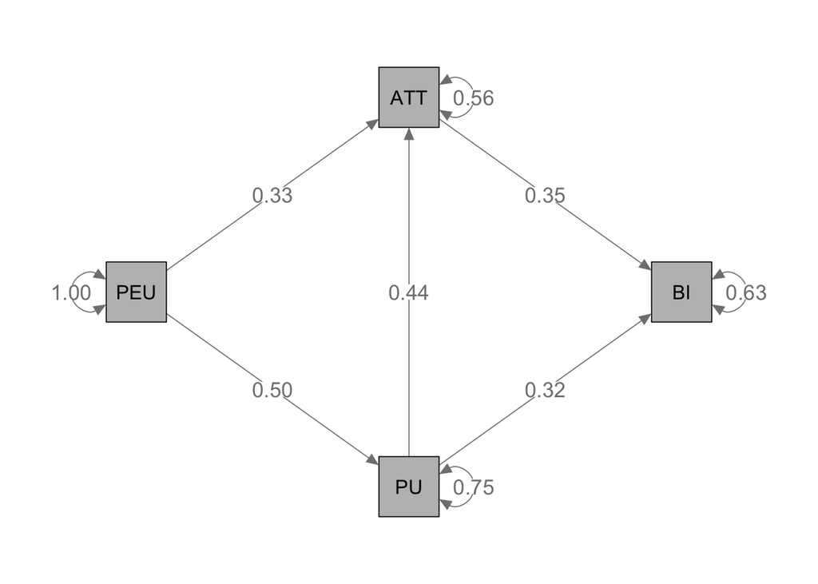

```r
# Visualize the model and add its parameters
TS.Model1.plot <- meta2semPlot(TS.Model1)
semPaths(TS.Model1.plot, whatLabels="est",
         rotation=2,
         edge.label.cex = 1.25,
         sizeMan = 8,
         color = "grey",
         layout = "tree2")
```

#### Model 2: Path model without the direct effect

In the first step, we specify the model using the `lavaan` language.

```r
# Model specification
Model2 <- " # Structural parameters
            BI ~ ATT
            ATT ~ PEU + PU
            PU ~ PEU

            # Variance of independent variables
            PEU ~~ 1*PEU
"

# Convert the model into the RAM language
RAM2 <- lavaan2RAM(Model2,
                  obs.variables = c("PU", "PEU", "ATT", "BI"))

# Declare the matrices in the RAM framework
# A: Matrix of factor loadings and regression coefficients
A2 <- RAM2$A
# S: Matrix of variances and covariances
S2 <- RAM2$S
# F: Matrix indicating manifest or latent variables (0=latent, 1=manifest)
F2 <- RAM2$F

# Check the RAM specification
# Note: The function remains silent if the specification is correct.
checkRAM(A2, S2, cor.analysis = TRUE)
```

This model is now estimated using the pooled correlation matrix obtained from the stage-1 REM.

```r
# Model estimation
# Confidence intervals are likelihood-ratio based (LBCIs)
TS.Model2 <- tssem2(rem, Amatrix=A2, Smatrix=S2, Fmatrix=F2,
                  intervals.type="LB",
                  diag.constraints = TRUE,
                  model.name = "Model 2 without the direct effect")

# Rerun the model to circumvent convergence issues and get all parameters
TS.Model2 <- rerun(TS.Model2)
```

```
## Polite note from mxTryHard: Hessian not checked as model contains mxConstraints
```

```
## Running Model 2 without the direct effect with 7 parameters
```

```
##
## Beginning initial fit attempt
```

```
## Running Model 2 without the direct effect with 7 parameters
```

```
##
##  Lowest minimum so far:  52.1716644058597
```

```
##
## Solution found
```

```
## Final run, for Hessian and/or standard errors and/or confidence intervals
```

```
## Running Model 2 without the direct effect with 7 parameters
```

```
##
##  Solution found!  Final fit=52.171664 (started at 377.12215)  (1 attempt(s): 1 valid, 0 errors)
```

```r
# Summarize the model parameters
summary(TS.Model2)
```

```
##
## Call:
## wls(Cov = pooledS, aCov = aCov, n = tssem1.obj$total.n, RAM = RAM,
##     Amatrix = Amatrix, Smatrix = Smatrix, Fmatrix = Fmatrix,
##     diag.constraints = diag.constraints, cor.analysis = cor.analysis,
##     intervals.type = intervals.type, mx.algebras = mx.algebras,
##     model.name = model.name, suppressWarnings = suppressWarnings,
##     silent = silent, run = run)
##
## 95% confidence intervals: Likelihood-based statistic
## Coefficients:
##            Estimate Std.Error  lbound  ubound z value Pr(>|z|)
## ATTONPEU    0.32656        NA 0.27283 0.37870      NA       NA
## ATTONPU     0.48260        NA 0.43557 0.52893      NA       NA
## BIONATT     0.63443        NA 0.59523 0.67385      NA       NA
## PUONPEU     0.48312        NA 0.44040 0.52585      NA       NA
## ATTWITHATT  0.50818        NA 0.46574 0.54856      NA       NA
## BIWITHBI    0.59750        NA 0.54592 0.64562      NA       NA
## PUWITHPU    0.76660        NA 0.72328 0.80609      NA       NA
##
## Goodness-of-fit indices:
##                                                 Value
## Sample size                                14918.0000
## Chi-square of target model                    52.1717
## DF of target model                             2.0000
## p value of target model                        0.0000
## Number of constraints imposed on "Smatrix"     3.0000
## DF manually adjusted                           0.0000
## Chi-square of independence model            3002.8445
## DF of independence model                       6.0000
## RMSEA                                          0.0410
## RMSEA lower 95% CI                             0.0318
## RMSEA upper 95% CI                             0.0510
## SRMR                                           0.0711
## TLI                                            0.9498
## CFI                                            0.9833
## AIC                                           48.1717
## BIC                                           32.9510
## OpenMx status1: 0 ("0" or "1": The optimization is considered fine.
## Other values indicate problems.)
```

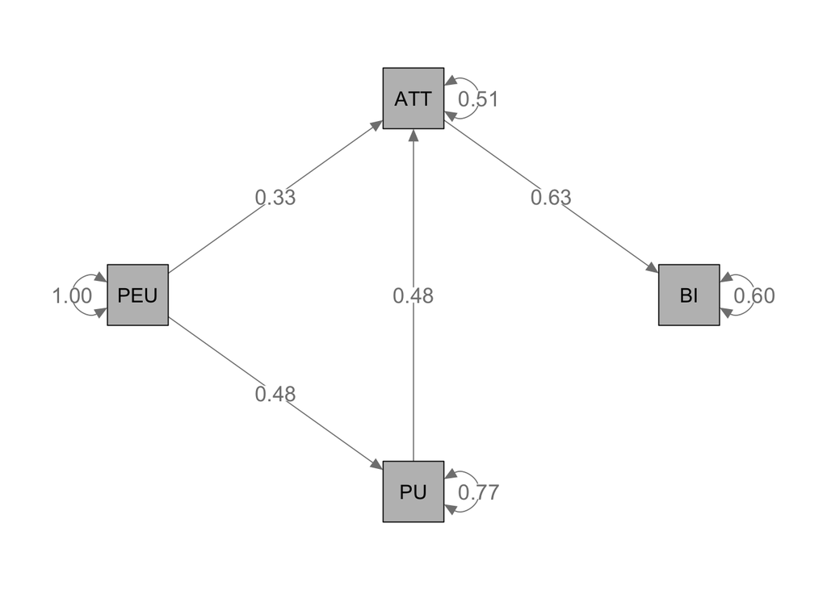

```r
# Visualize the model and add its parameters
TS.Model2.plot <- meta2semPlot(TS.Model2)
semPaths(TS.Model2.plot, whatLabels="est",
         rotation=2,
         edge.label.cex = 1.25,
         sizeMan = 8,
         color = "grey",
         layout = "tree2")
```

#### Model comparison: Model 1 vs. Model 2

```r
# Model comparison
anova(TS.Model1, TS.Model2)
```

```
##                             base                        comparison ep minus2LL
## 1 Model 1 with the direct effect                              <NA>  8 10.09000
## 2 Model 1 with the direct effect Model 2 without the direct effect  7 52.17166
##   df      AIC   diffLL diffdf            p
## 1 -5 26.09000       NA     NA           NA
## 2 -4 66.17166 42.08166      1 8.754026e-11
```

The chi-square different test suggest the preference of the model with the direct effect (`Model 1`) over the model without this effect (`Model 2`).

## One-Stage MASEM

### Data preparation

```r
## Convert the correlation matrices to a data frame
## Source: https://cran.r-project.org/web/packages/metaSEM/vignettes/Examples.html#one-stage-meta-analytic-structural-equation-modeling-osmasem
tamos <- Cor2DataFrame(TAMu$data, TAMu$n)
```

### Model 1

```r
## Pooling of correlation matrices and model estimation
M1_os <- osmasem(RAM = RAM,
                 model.name = "Model 1 OSMASEM",
                 data = tamos)

## Summarize the results
summary(M1_os)
```

```
## Summary of Model 1 OSMASEM
##
## free parameters:
##        name  matrix row col   Estimate  Std.Error A    z value     Pr(>|z|)
## 1   ATTONPU      A0 ATT  PU  0.4387429 0.02644554    16.590430 0.000000e+00
## 2    BIONPU      A0  BI  PU  0.3217157 0.04784739     6.723788 1.770606e-11
## 3   PUONPEU      A0  PU PEU  0.4982821 0.02179327    22.864034 0.000000e+00
## 4  ATTONPEU      A0 ATT PEU  0.3247803 0.03083009    10.534525 0.000000e+00
## 5   BIONATT      A0  BI ATT  0.3527154 0.04782889     7.374527 1.649791e-13
## 6    Tau1_1 vecTau1   1   1 -1.9209330 0.11309632   -16.984929 0.000000e+00
## 7    Tau1_2 vecTau1   2   1 -2.1517207 0.11428478   -18.827710 0.000000e+00
## 8    Tau1_3 vecTau1   3   1 -1.7457433 0.10938517   -15.959598 0.000000e+00
## 9    Tau1_4 vecTau1   4   1 -1.9578490 0.11418645   -17.146071 0.000000e+00
## 10   Tau1_5 vecTau1   5   1 -1.8521917 0.11779237   -15.724208 0.000000e+00
## 11   Tau1_6 vecTau1   6   1 -1.7164559 0.10860149   -15.805086 0.000000e+00
##
## To obtain confidence intervals re-run with intervals=TRUE
##
## Model Statistics:
##                |  Parameters  |  Degrees of Freedom  |  Fit (-2lnL units)
##        Model:             11                    289             -231.4163
##    Saturated:             27                    273                    NA
## Independence:             12                    288                    NA
## Number of observations/statistics: 14918/300
##
## Information Criteria:
##       |  df Penalty  |  Parameters Penalty  |  Sample-Size Adjusted
## AIC:      -809.4163              -209.4163                -209.3986
## BIC:     -3008.7999              -125.7028                -160.6599
## To get additional fit indices, see help(mxRefModels)
## timestamp: 2023-01-10 21:43:07
## Wall clock time: 0.5820432 secs
## optimizer:  SLSQP
## OpenMx version number: 2.20.7
## Need help?  See help(mxSummary)
```

```r
## SRMR
osmasemSRMR(M1_os)
```

```
## [1] 0.02843007
```

```r
## Extract the model coefficients
coef(M1_os)
```

```
##   ATTONPU    BIONPU   PUONPEU  ATTONPEU   BIONATT
## 0.4387429 0.3217157 0.4982821 0.3247803 0.3527154
```

```r
## Heterogeneity covariance matrix
VarCorr(M1_os)
```

```
##            Tau2_1     Tau2_2     Tau2_3     Tau2_4     Tau2_5     Tau2_6
## Tau2_1 0.02145353 0.00000000 0.00000000 0.00000000 0.00000000 0.00000000
## Tau2_2 0.00000000 0.01352194 0.00000000 0.00000000 0.00000000 0.00000000
## Tau2_3 0.00000000 0.00000000 0.03045556 0.00000000 0.00000000 0.00000000
## Tau2_4 0.00000000 0.00000000 0.00000000 0.01992664 0.00000000 0.00000000
## Tau2_5 0.00000000 0.00000000 0.00000000 0.00000000 0.02461539 0.00000000
## Tau2_6 0.00000000 0.00000000 0.00000000 0.00000000 0.00000000 0.03229278
```

### Model 2

```r
## Pooling of correlation matrices and model estimation
M2_os <- osmasem(RAM = RAM2,
                 model.name = "Model 2 OSMASEM",
                 data = tamos)

## Summarize the results
summary(M2_os)
```

```
## Summary of Model 2 OSMASEM
##
## free parameters:
##        name  matrix row col   Estimate  Std.Error A   z value Pr(>|z|)
## 1   ATTONPU      A0 ATT  PU  0.4744751 0.02629113    18.04696        0
## 2   PUONPEU      A0  PU PEU  0.4828779 0.02191621    22.03291        0
## 3  ATTONPEU      A0 ATT PEU  0.3255582 0.02936287    11.08741        0
## 4   BIONATT      A0  BI ATT  0.6486522 0.03316873    19.55613        0
## 5    Tau1_1 vecTau1   1   1 -1.9240153 0.11203448   -17.17342        0
## 6    Tau1_2 vecTau1   2   1 -2.1256321 0.11767463   -18.06364        0
## 7    Tau1_3 vecTau1   3   1 -1.5823385 0.12071540   -13.10801        0
## 8    Tau1_4 vecTau1   4   1 -1.9444599 0.11579528   -16.79222        0
## 9    Tau1_5 vecTau1   5   1 -1.8584046 0.12037083   -15.43899        0
## 10   Tau1_6 vecTau1   6   1 -1.5043851 0.13486545   -11.15471        0
##
## To obtain confidence intervals re-run with intervals=TRUE
##
## Model Statistics:
##                |  Parameters  |  Degrees of Freedom  |  Fit (-2lnL units)
##        Model:             10                    290             -196.7256
##    Saturated:             27                    273                    NA
## Independence:             12                    288                    NA
## Number of observations/statistics: 14918/300
##
## Information Criteria:
##       |  df Penalty  |  Parameters Penalty  |  Sample-Size Adjusted
## AIC:      -776.7256              -176.7256                -176.7108
## BIC:     -2983.7195              -100.6224                -132.4016
## To get additional fit indices, see help(mxRefModels)
## timestamp: 2023-01-10 21:43:08
## Wall clock time: 0.431143 secs
## optimizer:  SLSQP
## OpenMx version number: 2.20.7
## Need help?  See help(mxSummary)
```

```r
## SRMR
osmasemSRMR(M2_os)
```

```
## [1] 0.07279924
```

```r
## Extract the model coefficients
coef(M2_os)
```

```
##   ATTONPU   PUONPEU  ATTONPEU   BIONATT
## 0.4744751 0.4828779 0.3255582 0.6486522
```

```r
## Heterogeneity covariance matrix
VarCorr(M2_os)
```

```
##            Tau2_1     Tau2_2     Tau2_3     Tau2_4     Tau2_5     Tau2_6
## Tau2_1 0.02132169 0.00000000 0.00000000 0.00000000 0.00000000 0.00000000
## Tau2_2 0.00000000 0.01424621 0.00000000 0.00000000 0.00000000 0.00000000
## Tau2_3 0.00000000 0.00000000 0.04222778 0.00000000 0.00000000 0.00000000
## Tau2_4 0.00000000 0.00000000 0.00000000 0.02046744 0.00000000 0.00000000
## Tau2_5 0.00000000 0.00000000 0.00000000 0.00000000 0.02431142 0.00000000
## Tau2_6 0.00000000 0.00000000 0.00000000 0.00000000 0.00000000 0.04935234
```

### Model comparison: Model 1 vs. Model 2

```r
## Model comparison
anova(M1_os, M2_os)
```

```
##              base      comparison ep  minus2LL  df       AIC   diffLL diffdf
## 1 Model 1 OSMASEM            <NA> 11 -231.4163 289 -209.4163       NA     NA
## 2 Model 1 OSMASEM Model 2 OSMASEM 10 -196.7256 290 -176.7256 34.69073      1
##              p
## 1           NA
## 2 3.864676e-09
```